# Problem set 04

Lukas Sonderegger 49057870

2 März 2018

### Problem set 04

```r
library(kableExtra)
library(knitr)
library(tidyverse)
library(vegan)
```

#### Part 1

```r
data1 = data.frame(
  number = c(1:32),
  name = c("m&m green", "m&m red", "m&m blue", "m&m yellow", "m&m brown", "m&m orange", "skittle brown", "skittle red", "skittle green", "skittle orange", "skittle yellow", "bear red", "bear pink", "bear green", "bear orange", "bear yellow", "bear white", "m&i pink", "m&i green", "m&i yellow", "m&i orange", "m&i red", "worms red", "balls yellow", "balls green", "balls purple", "balls orange", "balls red", "chocolate kiss", "lego pink", "lego yellow", "lego blue" ),
  characteristics = c("m&m green", "m&m red", "m&m blue", "m&m yellow", "m&m brown", "m&m orange", "skittle brown", "skittle red", "skittle green", "skittle orange", "skittle yellow", "bear red", "bear pink", "bear green", "bear orange", "bear yellow", "bear white", "m&i pink", "m&i green", "m&i yellow", "m&i orange", "m&i red", "worms red", "balls yellow", "balls green", "balls purple", "balls orange", "balls red", "chocolate kiss", "lego pink", "lego yellow", "lego blue"),
  occurences = c(28,28,60,44,30,63,39,33,42,35,23,15,16,18,15,19,16,39,36,27,32,40,14,4,5,3,5,7,16,7,5,4)
)

data1 %>%
  kable("html") %>%
  kable_styling(bootstrap_options = "striped", font_size = 10, full_width = F)
```

| number | name | characteristics | occurences |
| --- | --- | --- | --- |
| 1 | m&m green | m&m green | 28 |
| 2 | m&m red | m&m red | 28 |
| 3 | m&m blue | m&m blue | 60 |
| 4 | m&m yellow | m&m yellow | 44 |
| 5 | m&m brown | m&m brown | 30 |
| 6 | m&m orange | m&m orange | 63 |
| 7 | skittle brown | skittle brown | 39 |
| 8 | skittle red | skittle red | 33 |
| 9 | skittle green | skittle green | 42 |
| 10 | skittle orange | skittle orange | 35 |
| 11 | skittle yellow | skittle yellow | 23 |
| 12 | bear red | bear red | 15 |
| 13 | bear pink | bear pink | 16 |
| 14 | bear green | bear green | 18 |
| 15 | bear orange | bear orange | 15 |
| 16 | bear yellow | bear yellow | 19 |
| 17 | bear white | bear white | 16 |
| 18 | m&i pink | m&i pink | 39 |
| 19 | m&i green | m&i green | 36 |
| 20 | m&i yellow | m&i yellow | 27 |
| 21 | m&i orange | m&i orange | 32 |
| 22 | m&i red | m&i red | 40 |
| 23 | worms red | worms red | 14 |
| 24 | balls yellow | balls yellow | 4 |
| 25 | balls green | balls green | 5 |
| 26 | balls purple | balls purple | 3 |
| 27 | balls orange | balls orange | 5 |
| 28 | balls red | balls red | 7 |
| 29 | chocolate kiss | chocolate kiss | 16 |
| 30 | lego pink | lego pink | 7 |
| 31 | lego yellow | lego yellow | 5 |
| 32 | lego blue | lego blue | 4 |

#### Ask yourself if your collection of microbial cells from seawater represents the actual diversity of microorganisms inhabiting waters along the Line-P transect. Were the majority of different species sampled or were many missed?

There might be many species missed, as we only have 32 different species

#### Part 2

```r
y = c(1,2,3,4,5,6,7,7,7,8,9,9,10,11,12,13,14,15,16,16,17,18,18,18,19,19,19,19,19,20,20,20,21,21,21,21,21,22,22,22,22,22,22,23,23,23,23,23,23,24,24,24,24,24,24,24,25,25,25,25,25,25,25,25,25,26,26,26,26,26,26,26,26,27,27,27,27,27,27,27,27,27,28,28,28,28,28,28,28,28,28,29,29,29,29,29,29,29,29,29,29,30,30,30,30,30,30,30,30,30,30,31,31,31,31,31,31,31,31,31,31,31,31)

data2 = data.frame(

  y = c(1,2,3,4,5,6,7,7,7,8,9,9,10,11,12,13,14,15,16,16,17,18,18,18,19,19,19,19,19,20,20,20,21,21,21,21,21,22,22,22,22,22,22,23,23,23,23,23,23,24,24,24,24,24,24,24,25,25,25,25,25,25,25,25,25,26,26,26,26,26,26,26,26,27,27,27,27,27,27,27,27,27,28,28,28,28,28,28,28,28,28,29,29,29,29,29,29,29,29,29,29,30,30,30,30,30,30,30,30,30,30,31,31,31,31,31,31,31,31,31,31,31,31),
  x = c(1: length(y))
)
```

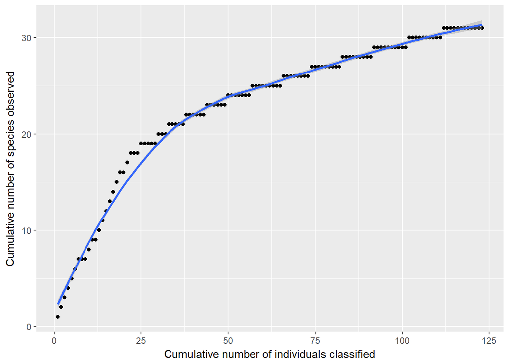

```r
ggplot(data2, aes(x=x, y=y)) +
  geom_point() +
  geom_smooth() +
  labs(x="Cumulative number of individuals classified", y="Cumulative number of species observed")
```

#### Does the curve flatten out? If so, after how many individual cells have been collected?

The curve does not flatten out completely, however, the slope decreases strongly after 20 observed species

#### What can you conclude from the shape of your collector’s curve as to your depth of sampling?

From the shape of the collectors curve, there would be more species expected to be discovered if the sample was bigger

#### Part 3

```r
sum_occurence = sum (data1 %>%
  select(occurences))

spec_occurence = c()
for (i in 1:32) {
  spec_occurence[i] = data1 %>%
            filter(number == i) %>%
              select(occurences)
}
spec_occurence= unlist(spec_occurence)


spec_occurence
```

```
##  [1] 28 28 60 44 30 63 39 33 42 35 23 15 16 18 15 19 16 39 36 27 32 40 14
## [24]  4  5  3  5  7 16  7  5  4
```

```r
spec_p =c()
for (i in 1: 32){
  spec_p[i] = spec_occurence[i] / sum_occurence
}

spec_p2= spec_p^2

D= 1 / sum(spec_p2)
D
```

```
## [1] 22.18718
```

-> The Simpson Reciprocal Index for the total community is 22.187

```r
data_sample = data.frame(
  number = c(1:32),
  name = c("m&m green", "m&m red", "m&m blue", "m&m yellow", "m&m brown", "m&m orange", "skittle brown", "skittle red", "skittle green", "skittle orange", "skittle yellow", "bear red", "bear pink", "bear green", "bear orange", "bear yellow", "bear white", "m&i pink", "m&i green", "m&i yellow", "m&i orange", "m&i red", "worms red", "balls yellow", "balls green", "balls purple", "balls orange", "balls red", "chocolate kiss", "lego pink", "lego yellow", "lego blue" ),
  characteristics = c("m&m green", "m&m red", "m&m blue", "m&m yellow", "m&m brown", "m&m orange", "skittle brown", "skittle red", "skittle green", "skittle orange", "skittle yellow", "bear red", "bear pink", "bear green", "bear orange", "bear yellow", "bear white", "m&i pink", "m&i green", "m&i yellow", "m&i orange", "m&i red", "worms red", "balls yellow", "balls green", "balls purple", "balls orange", "balls red", "chocolate kiss", "lego pink", "lego yellow", "lego blue"),
  occurences = c(8,7,6,2,9,1,7,7,5,2,5,2,2,2,1,5,2,5,4,5,11,7,1,6,1,1,2,2,3,1,2,0)
)

sample3=c(8,7,6,2,9,1,7,7,5,2,5,2,2,2,1,5,2,5,4,5,11,7,1,6,1,1,2,2,3,1,2,0)
sum3=sum(sample3)
spec_p3 =c()
for (i in 1: 32){
  spec_p3[i] = sample3[i] / sum3
}

spec_p3= spec_p3^2

D= 1 / sum(spec_p3)
D
```

```
## [1] 21.17906
```

-> The Simpson Reciprocal Index for my sample is 21.179

```r
schao_tot = 32 + 0
schao_tot
```

```
## [1] 32
```

```r
schao_sample= 31 + (6^2 / (2*25))
schao_sample
```

```
## [1] 31.72
```

#### Part4

```r
data1_diversity =
  data1 %>%
  select(name, occurences) %>%
  spread(name, occurences)

data1_diversity
```

```
##   balls green balls orange balls purple balls red balls yellow bear green
## 1           5            5            3         7            4         18
##   bear orange bear pink bear red bear white bear yellow chocolate kiss
## 1          15        16       15         16          19             16
##   lego blue lego pink lego yellow m&i green m&i orange m&i pink m&i red
## 1         4         7           5        36         32       39      40
##   m&i yellow m&m blue m&m brown m&m green m&m orange m&m red m&m yellow
## 1         27       60        30        28         63      28         44
##   skittle brown skittle green skittle orange skittle red skittle yellow
## 1            39            42             35          33             23
##   worms red
## 1        14
```

```r
diversity(data1_diversity, index="invsimpson")
```

```
## [1] 22.18718
```

```r
specpool(data1_diversity)
```

```
##     Species chao chao.se jack1 jack1.se jack2 boot boot.se n
## All      32   32       0    32        0    32   32       0 1
```

```r
datasample_diversity =
  data_sample %>%
  select(name, occurences) %>%
  spread(name, occurences)

diversity(datasample_diversity, index="invsimpson")
```

```
## [1] 21.17906
```

```r
specpool(datasample_diversity)
```

```
##     Species chao chao.se jack1 jack1.se jack2 boot boot.se n
## All      31   31       0    31        0    31   31       0 1
```

-> Simpson index for total community: 22.187  
-> Simpson index for my sample: 21.179  
-> Chao1 for total community: 32  
-> Chao1 for my sample: 31

#### Part 5

##### How does the measure of diversity depend on the definition of species in your samples?

If we assign more CFUs to the same species, we end up with less different species and therefore less diversity. Or, if different species definitions lead to the same number of species, but with different abundance-proportions amongst the species, the diversity might again be different.

#### Can you think of alternative ways to cluster or bin your data that might change the observed number of species?

We could have sorted the candies just by color, regardless of their shape, brand.  
Another alternative would have been to ignore the color and sort the candies only by the shape, type (e.g. assign all m&m’s to the same species and all skittels to another one..)

#### How might different sequencing technologies influence observed diversity in a sample?

The observed diversity might be overestimated, if a more error-prone sequencing method is applied. More errors in base calling leads to higher diversity in sequences, leading to a higher number of estimated species.  
Second generation sequencing often has higher error rates and produces shorter reads than sanger sequencing. This leads to overestimated diversity, especially when reads with unresolved bases or abnormal read lenghts are removed from the data.[Kunin et al. 2010](https://www.ncbi.nlm.nih.gov/pubmed/19725865)